# Final Presentation

December 13, 2022 @ 02:01 PM

## Packages Used

I used tidyverse for data manipulation and plotting.

```r
library(tidyverse)
```

## Data Analyst Job Postings Dataset

**Variables in the Dataset:**

- `index`: file original index
- `title`: job title listed in job posting
- `company_name`: the company that listed the job posting
- `location`: city and state
- `via`: social media platform that posted the job listing
- `description`: full description from the job posting
- `extensions`: common keywords for job postings
- `posted_at`: time posted in reference to `data_time` column
- `schedule_type`: full-time, part-time, or contract type job
- `work_from_home`: True or NA (blank)
- `search_term`: search term in google to get job posting results
- `date_time`: date and time job pulled from google
- `search_location`: search location in google to get job posting results

I removed columns that were practically empty and removed the word “via” from the `via` column.

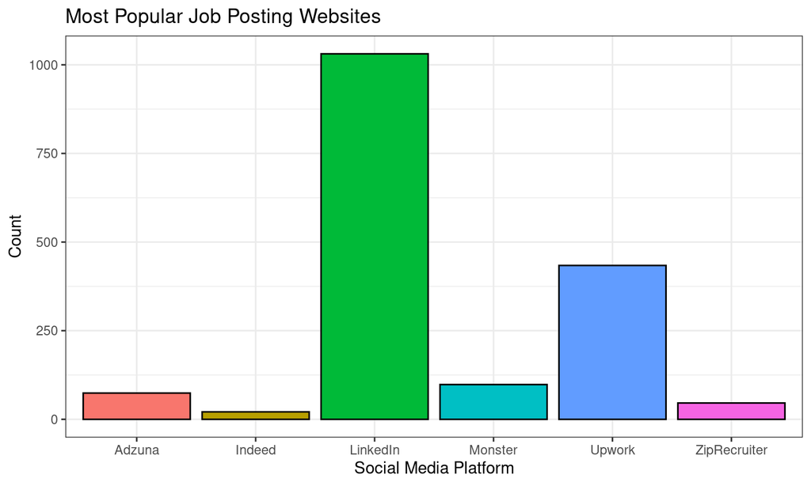

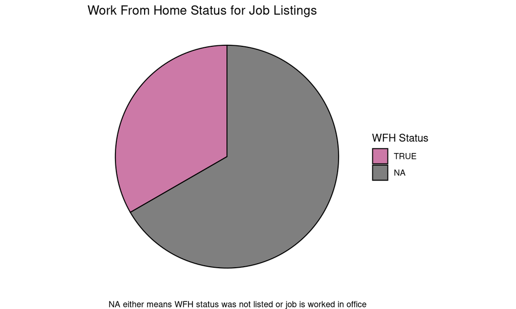

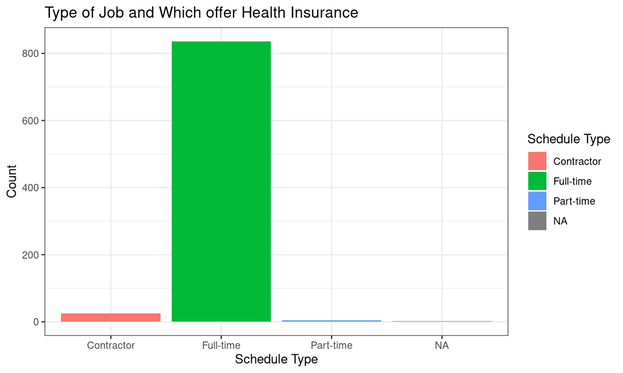